# Text Preprocessing

Rafael H. Vareto

## Tokenizers

**NLTK** é uma plataforma líder para a construção de programas Python para trabalhar com dados de linguagem humana. Ele fornece interfaces fáceis de usar para mais de 50 corpora e recursos lexicais, como WordNet, junto com um pacote de bibliotecas de processamento de texto para classificação, tokenização, lematização, marcação, análise e raciocínio semântico, wrappers para bibliotecas de PNL de força industrial, e um fórum de discussão ativo.

```python
'''
Importanto modulos necessarios
Tokenizer:
'''
import nltk
import nltk.data

nltk.download('punkt')
```

```
True
```

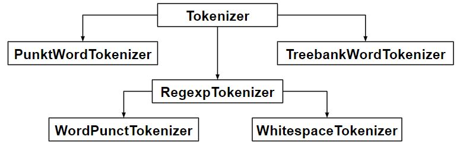

**Tokenizer de sentenças**

Este tokenizer divide um texto em uma lista de frases, usando um algoritmo não supervisionado para construir um modelo para abreviações de palavras, colocações e palavras que iniciam frases.

```python
# realizando o processo de tokenização
grande_sertao_text = "Sou só o sr. sertanejo, nessas altas ideias navego mal. Sou muito pobre coitado. Inveja minha pura é de uns conforme o senhor, com toda leitura e suma doutoração."
```

```python
# tokenização de sentenças em pt-br
from nltk.tokenize import sent_tokenize
sentence_list = sent_tokenize(grande_sertao_text)
sentence_list
```

```
['Sou só o sr. sertanejo, nessas altas ideias navego mal.',
 'Sou muito pobre coitado.',
 'Inveja minha pura é de uns conforme o senhor, com toda leitura e suma doutoração.']
```

```python
# carregando tokenizer PUNKT adaptado para lingua portuguesa
ptbr_sentence = nltk.data.load('tokenizers/punkt/PY3/portuguese.pickle')

# tokenização de sentenças em pt-br
sentence_list = ptbr_sentence.tokenize(grande_sertao_text)
sentence_list
```

```
['Sou só o sr. sertanejo, nessas altas ideias navego mal.',
 'Sou muito pobre coitado.',
 'Inveja minha pura é de uns conforme o senhor, com toda leitura e suma doutoração.']
```

**Sentence tokenizers** sabem que os pontos do "sr. sertanejo" não definem os limites das sentenças.

Alem do mais, frases podem começar com palavras minúsculas.

**Tokenizer de palavras**

Os tokenizadores dividem as strings em listas de substrings.

Por exemplo, os tokenizadores podem ser usados para encontrar as palavras e pontuação em uma string

```python
print(sentence_list[0])
```

```
Sou só o sr. sertanejo, nessas altas ideias navego mal.
```

```python
# tokenizacao de palavras
from nltk.tokenize import word_tokenize
first_sentence = word_tokenize(sentence_list[0])
print(first_sentence)
```

```
['Sou', 'só', 'o', 'sr.', 'sertanejo', ',', 'nessas', 'altas', 'ideias', 'navego', 'mal', '.']
```

**Tokenizadores de expressão regular**

Um *RegexpTokenizer* divide uma string em substrings usando uma expressão regular. Por exemplo, o seguinte tokenizer forma tokens de sequências alfabéticas, expressões monetárias e quaisquer outras sequências que não sejam espaços em branco:

```python
# tokenização utilizando expressões regulares
from nltk.tokenize import RegexpTokenizer
regex_tker = RegexpTokenizer("[\w]+[\.]*")
print(regex_tker.tokenize(sentence_list[0]))
```

```
['Sou', 'só', 'o', 'sr.', 'sertanejo', 'nessas', 'altas', 'ideias', 'navego', 'mal.']
```

```python
minas_sentence = "Bons pães de queijo custam $2.50\nem Belo Horizonte.  Por favor compre\ncinco.\n\nObrigado."
tokenizer = RegexpTokenizer("\w+|\$[\d\.]+|\S+")
print(tokenizer.tokenize(minas_sentence))
```

```
['Bons', 'pães', 'de', 'queijo', 'custam', '$2.50', 'em', 'Belo', 'Horizonte', '.', 'Por', 'favor', 'compre', 'cinco', '.', 'Obrigado', '.']
```

## WordNet

O WordNet é um banco de dados lexical de relações semânticas entre palavras em mais de 200 idiomas. O WordNet vincula palavras a relações semânticas, incluindo sinônimos, hiponímias e merônimos.

```python
# o dicionário de sinonimos (thesaurus) funciona bem no inglês
from nltk.corpus import wordnet
nltk.download('wordnet')
```

```
True
```

```python
word_synset = wordnet.synsets('study')
word_synset
```

```
[Synset('survey.n.01'),
 Synset('study.n.02'),
 Synset('report.n.01'),
 Synset('study.n.04'),
 Synset('study.n.05'),
 Synset('discipline.n.01'),
 Synset('sketch.n.01'),
 Synset('cogitation.n.02'),
 Synset('study.n.09'),
 Synset('study.n.10'),
 Synset('analyze.v.01'),
 Synset('study.v.02'),
 Synset('study.v.03'),
 Synset('learn.v.04'),
 Synset('study.v.05'),
 Synset('study.v.06')]
```

```python
for ws in word_synset:
    print(ws, ws.definition())
```

```
Synset('survey.n.01') a detailed critical inspection
Synset('study.n.02') applying the mind to learning and understanding a subject (especially by reading)
Synset('report.n.01') a written document describing the findings of some individual or group
Synset('study.n.04') a state of deep mental absorption
Synset('study.n.05') a room used for reading and writing and studying
Synset('discipline.n.01') a branch of knowledge
Synset('sketch.n.01') preliminary drawing for later elaboration
Synset('cogitation.n.02') attentive consideration and meditation
Synset('study.n.09') someone who memorizes quickly and easily (as the lines for a part in a play)
Synset('study.n.10') a composition intended to develop one aspect of the performer's technique
Synset('analyze.v.01') consider in detail and subject to an analysis in order to discover essential features or meaning
Synset('study.v.02') be a student; follow a course of study; be enrolled at an institute of learning
Synset('study.v.03') give careful consideration to
Synset('learn.v.04') be a student of a certain subject
Synset('study.v.05') learn by reading books; I must hit the books now"
Synset('study.v.06') think intently and at length, as for spiritual purposes
```

## Radical vs Lema

**Lematização** é, pois, a representação da palavra através de seu masculino singular, adjetivos e substantivos e infinitivo (verbos), apenas no contexto da lexicologia. **Stemming** é a retirada de sufixos do radical, enquanto **stem (radical)** é o próprio radical.

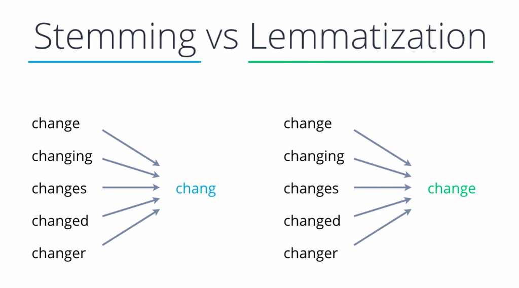

### Stemming

```python
# Obtendo algoritmo de radicalização (stemming) para a língua portuguesa
nltk.download('rslp')
stemmer_portuguese = nltk.stem.RSLPStemmer()
```

```python
print(stemmer_portuguese.stem("copiar"))
```

```
copi
```

```python
stemmer_portuguese.stem("casarão")
```

```
'cas'
```

### Lemmatization

**Stanza** é um kit de ferramentas Python PNL que suporta mais de 60 linguagens humanas. Ele é construído com componentes de rede neural altamente precisos que permitem treinamento e avaliação eficientes com seus próprios dados anotados e oferece modelos pré-treinados em 100 treebanks. Além disso, o Stanza fornece uma interface Python estável e oficialmente mantida para o Java Stanford CoreNLP Toolkit.

```python
!pip install stanza
```

```
     |████████████████████████████████| 286kB 5.8MB/s
```

```python
# Modulo instalado pelo commando !pip no inicio do notebook
import stanza
import random
```

```python
stanza.download('pt')
nlp = stanza.Pipeline('pt')
```

[output not shown]

```python
cs_lewis_quote = "Eu descobri em mim mesmo desejos os quais nada nesta Terra pode satisfazer. A única explicação lógica é que eu fui feito para outro mundo."

for token in nlp(cs_lewis_quote).sentences:
    text = str()
    lemma = str()
    for word in token.words:
        text += word.text + "\t"
        lemma += word.lemma + "\t"
    print('TEXTO:', text)
    print('LEMMA:', lemma)
```

```
TEXTO: Eu	descobri	em	mim	mesmo	desejos	os	quais	nada	em	esta	Terra	pode	satisfazer	.
LEMMA: eu	descobrir	em	eu	mesmo	desejo	o	qual	nada	em	este	terra	poder	satisfazer	.
TEXTO: A	única	explicação	lógica	é	que	eu	fui	feito	para	outro	mundo	.
LEMMA: o	único	explicação	lógico	ser	que	eu	ser	fazer	para	outro	mundo	.
```

```python
for token in nlp(cs_lewis_quote).sentences:
    print(token)
```

[output not shown]

[output cut: 228 more lines]

[output not shown]

## Análise de sentimentos

**TextBlob** visa fornecer acesso a operações comuns de processamento de texto por meio de uma interface familiar. Você pode tratar objetos TextBlob como se fossem strings de Python que aprenderam a fazer processamento de linguagem natural.

TextBlob é baseado em NLTK e fornece uma interface fácil de usar para a biblioteca NLTK. Veremos como o TextBlob pode ser usado para realizar uma variedade de tarefas de PLN, desde marcação de partes do discurso até análise de sentimento e tradução de idioma para classificação de texto. [API link](https://textblob.readthedocs.io/en/dev/)

```python
from textblob import TextBlob
```

```python
quote_01 = "One of the best things in life is to be free."
quote_02 = "I hate waiting too long in queues. Feels like I'm wasting my time."

quote_03 = "I can't imagine a man really enjoying a book and reading it only once."
quote_04 = "You can never get a cup of tea large enough or a book long enough to suit me."
quote_05 = "Education without values, as useful as it is, seems rather to make man a more clever devil."
```

```python
quoteblob_01 = TextBlob(quote_01)
quoteblob_02 = TextBlob(quote_02)
quoteblob_03 = TextBlob(quote_03)
quoteblob_04 = TextBlob(quote_04)
quoteblob_05 = TextBlob(quote_05)
```

```python
print(quoteblob_01.sentiment) # "One of the best things in life is to be free."
print(quoteblob_02.sentiment) # "I hate waiting too long in queues. Feels like I'm wasting my time."
```

```
Sentiment(polarity=0.7, subjectivity=0.55)
Sentiment(polarity=-0.42500000000000004, subjectivity=0.65)
```

```python
print(quoteblob_03.sentiment) # "I can't imagine a man really enjoying a book and reading it only once."
print(quoteblob_04.sentiment) # "You can never get a cup of tea large enough or a book long enough to suit me."
print(quoteblob_05.sentiment) # "Education without values, as useful as it is, seems rather to make man a more clever devil."
```

```
Sentiment(polarity=0.25, subjectivity=0.8)
Sentiment(polarity=0.041071428571428564, subjectivity=0.4571428571428572)
Sentiment(polarity=0.32222222222222224, subjectivity=0.4444444444444445)
```

**Obs.:** A propriedade *sentimento* retorna uma dupla nomeada da forma `Sentiment(polaridade, subjetividade)`. A polaridade é um ponto flutuante dentro do intervalo [-1.0, 1.0]. A *subjetividade* é uma flutuação dentro do intervalo [0.0, 1.0], onde 0.0 é muito objetivo e 1.0 é muito subjetivo.

## Tradução de sentenças

### Google Translator

**Googletrans** é uma biblioteca python gratuita e ilimitada que implementou a API do Google Translate. Isso usa a API Ajax do Google Translate para fazer chamadas para métodos como detectar e traduzir. [GitHub repository link](https://github.com/ssut/py-googletrans)

```python
!pip install googletrans==4.0.0rc1
```

```
     |████████████████████████████████| 61kB 2.9MB/s
     |████████████████████████████████| 51kB 3.5MB/s
     |████████████████████████████████| 1.0MB 5.5MB/s
     |████████████████████████████████| 71kB 5.4MB/s
     |████████████████████████████████| 61kB 4.2MB/s
```

```python
import googletrans
from googletrans import Translator as google_translator

translator = google_translator()
```

```python
sentence_01 = 'Friendship is unnecessary, like philosophy, like art.... It has no survival value; rather it is one of those things which give value to survival.'
result = translator.translate(sentence_01, dest='pt', src='en')
print(result.text)
```

```
A amizade é desnecessária, como filosofia, como arte ... não tem valor de sobrevivência;Em vez disso, é uma daquelas coisas que dão valor à sobrevivência.
```

```python
sentence_02 = 'Eu descobri em mim mesmo desejos os quais nada desta terra pode satisfazer. A única explicação lógica e que eu fui feito para outro mundo.'
result = translator.translate(sentence_02, dest='en', src='pt')
print(result.text)
```

```
I discovered in myself desires which nothing of this earth can satisfy.The only logical explanation and that I was made to another world.
```

```python
sentence_03 = 'I believe in Christianity as I believe that the sun has risen: not only because I see it, but because by it I see everything else.'
result = translator.translate(sentence_03, dest='it', src='en')
print(result.text)
```

```
Credo nel cristianesimo perché credo che il sole sia risorto: non solo perché lo vedo, ma perché da ciò vedo tutto il resto.
```

### TextBlob Translator

**TextBlob** é baseado em NLTK e fornece uma interface fácil de usar para a biblioteca NLTK. Veremos como o TextBlob pode ser usado para realizar uma variedade de tarefas de PLN, desde marcação de partes do discurso até análise de sentimento e tradução de idioma para classificação de texto. API link

```python
from textblob import TextBlob

# Obs: pode ser necessário declarar a string como unicode para que ele funcione corretamente.
```

```python
sentence_01 = u'Friendship is unnecessary, like philosophy, like art... It has no survival value; rather it is one of those things which give value to survival.'
language_translator = TextBlob(sentence_01)
result = language_translator.translate(from_lang='en', to='pt')
print(result)
print(result.sentiment)
```

```
A amizade é desnecessária, como a filosofia, como a arte ... Não tem valor de sobrevivência; antes, é uma daquelas coisas que dão valor à sobrevivência.
Sentiment(polarity=0.0, subjectivity=0.0)
```

```python
sentence_02 = u'Eu descobri em mim mesmo desejos os quais nada desta terra pode satisfazer. A única explicação lógica e que eu fui feito para outro mundo.'
language_translator = TextBlob(sentence_02)
result = language_translator.translate(from_lang='pt', to='en')
print(result)
print(result.sentiment)
```

```
I discovered in myself desires which nothing on this earth can satisfy. The only logical explanation is that I was made for another world.
Sentiment(polarity=0.125, subjectivity=0.625)
```

```python
sentence_03 = u'I believe in Christianity as I believe that the sun has risen: not only because I see it, but because by it I see everything else.'
language_translator = TextBlob(sentence_03)
result = language_translator.translate(from_lang='en', to='it')
print(result)
print(result.sentiment)
```

```
Credo nel cristianesimo come credo che il sole sia sorto: non solo perché lo vedo, ma perché da esso vedo tutto il resto.
Sentiment(polarity=0.0, subjectivity=0.25)
```

- [GoogleTranslator] A amizade é desnecessária, como filosofia, como arte ... não tem valor de sobrevivência; Em vez disso, é uma daquelas coisas que dão valor à sobrevivência.
- [TextBlob] A amizade é desnecessária, como a filosofia, como a arte ... Não tem valor de sobrevivência; antes, é uma daquelas coisas que dão valor à sobrevivência.
- [GoogleTranslator] I discovered in myself desires which nothing of this earth can satisfy.The only logical explanation and that I was made to another world.
- [TextBlob] I discovered in myself desires which nothing on this earth can satisfy. The only logical explanation is that I was made for another world.
- [GoogleTranslator] Credo nel cristianesimo perché credo che il sole sia risorto: non solo perché lo vedo, ma perché da ciò vedo tutto il resto.
- [TextBlob] Credo nel cristianesimo come credo che il sole sia sorto: non solo perché lo vedo, ma perché da esso vedo tutto il resto.

## spaCy

**spaCy** uma bilbioteca Python para Processamento de Linguagem Natural (NLP).

Você pode usar qualquer modelo pré-treinado para treinar seus próprios pipelines e até mesmo compartilhar um modelo entre vários componentes com aprendizado multitarefa.

```python
# baixar e instalar modelo pré-treinado na lingua portuguesa
!python -m spacy download pt

import spacy
```

```
     |████████████████████████████████| 21.2MB 1.2MB/s
✔ Download and installation successful
You can now load the model via spacy.load('pt_core_news_sm')
✔ Linking successful
/usr/local/lib/python3.7/dist-packages/pt_core_news_sm -->
/usr/local/lib/python3.7/dist-packages/spacy/data/pt
You can now load the model via spacy.load('pt')
```

```python
nlp_en = spacy.load('en') # default spacy language
nlp_pt = spacy.load('pt')
```

**Análise de classes gramaticais:** etiquetamento morfologico.

Podemos também entender as classes gramaticais de cada palavra dentro do nosso contexto.

```python
sentence_en = "A children's story that can only be enjoyed by children is not a good children's story in the slightest."
result = nlp_en(sentence_en)
[(token.orth_, token.pos_) for token in result]
```

```
[('A', 'DET'),
 ('children', 'NOUN'),
 ("'s", 'PART'),
 ('story', 'NOUN'),
 ('that', 'DET'),
 ('can', 'VERB'),
 ('only', 'ADV'),
 ('be', 'AUX'),
 ('enjoyed', 'VERB'),
 ('by', 'ADP'),
 ('children', 'NOUN'),
 ('is', 'AUX'),
 ('not', 'PART'),
 ('a', 'DET'),
 ('good', 'ADJ'),
 ('children', 'NOUN'),
 ("'s", 'PART'),
 ('story', 'NOUN'),
 ('in', 'ADP'),
 ('the', 'DET'),
 ('slightest', 'ADJ'),
 ('.', 'PUNCT')]
```

```python
sentence_pt = "Tudo que é eterno está eternamente acima do tempo."
result = nlp_pt(sentence_pt)
[(token.orth_, token.pos_) for token in result]
```

```
[('Tudo', 'PRON'),
 ('que', 'PRON'),
 ('é', 'VERB'),
 ('eterno', 'ADJ'),
 ('está', 'VERB'),
 ('eternamente', 'ADV'),
 ('acima', 'ADV'),
 ('do', 'ADP'),
 ('tempo', 'NOUN'),
 ('.', 'PUNCT')]
```

O **spaCy** também permite avaliar similaridade entre palavras. O método .similarity de um Token avalia a similaridade semântica estimada entre as palavras. Quanto maior o valor, mais similar são as palavras.

```python
sentence_pt = "Mera mudança não é crescimento. Crescimento é a síntese de mudança e continuidade, e onde não há continuidade não há crescimento."
result = nlp_pt(sentence_pt)
tokens = [token for token in result]

print(tokens[1], tokens[9], tokens[1].similarity(tokens[9]))
print(tokens[11], tokens[13], result[11].similarity(result[13]))
```

```
mudança síntese 0.22755378
mudança continuidade 0.51709765
```